# Financiamiento y eficiencia hospitalaria

## R Markdown

This is an R Markdown document themed with [`{bslib}` package](https://rstudio.github.io/bslib/). `{bslib}` makes it easy to customize the main colors and fonts of a `html_document`, [`flexdashboard::flex_dashboard`](https://flexdashboard-pkg.netlify.app/articles/articles/theme.html), [shiny::fluidPage()](https://shiny.rstudio.com/reference/shiny/latest/fluidPage.html), or more generally any website that uses [Bootstrap](https://getbootstrap.com/) for styling. The `theme` parameter in the yaml front-matter of this Rmd document describes a [`bslib::bs_theme()`](https://rstudio.github.io/bslib/reference/bs_theme.html) object. This particular example uses Bootstrap 3 (`version: 3`), which is primarily for ‘legacy’ documents that would break with Bootstrap 4 or above.

## Themed Plots

### Costos directos

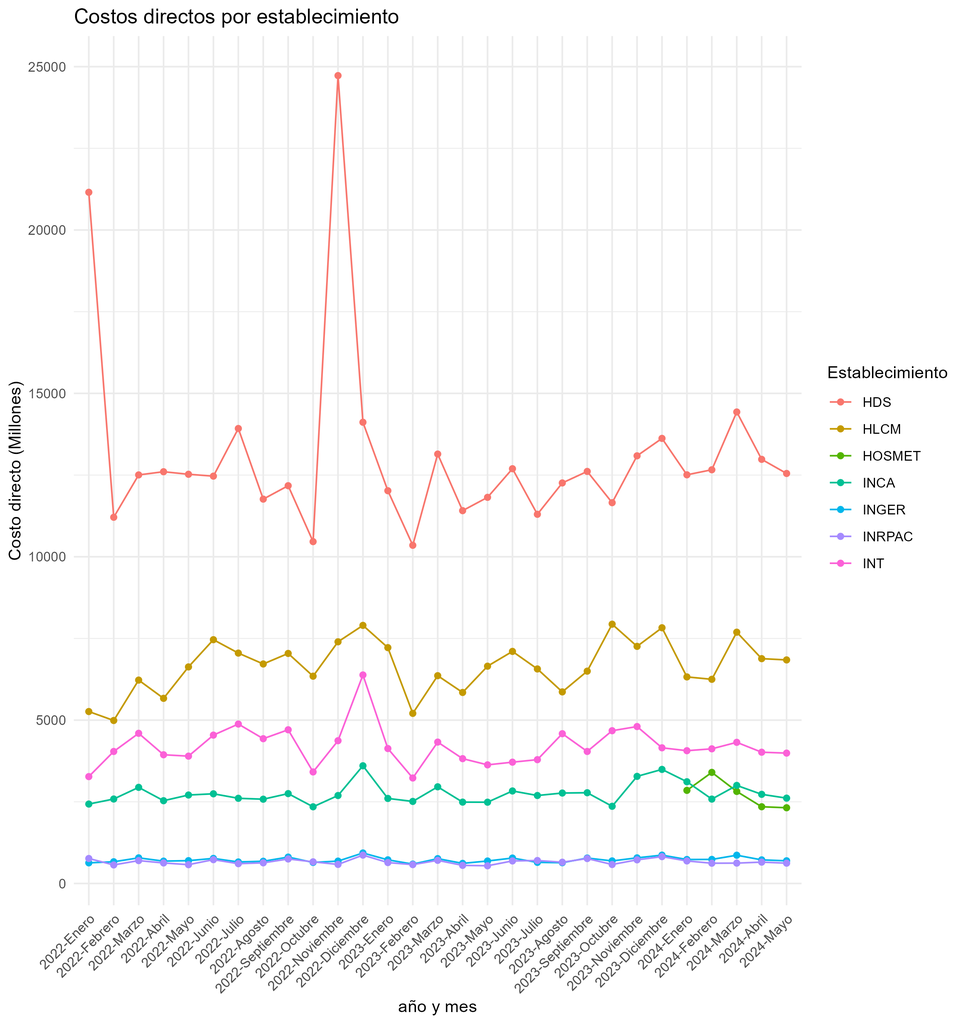

## Costo directo promedio mensual

|  | Establecimiento | Costo directo promedio Mensual |
| --- | --- | --- |
| 1 | HDS | 13129.12679499319 |
| 2 | HLCM | 6655.450024148508 |
| 3 | HOSMET | 2746.915886785964 |
| 4 | INCA | 2752.439249586518 |
| 5 | INGER | 722.7459378839999 |
| 6 | INRPAC | 663.3687475233908 |
| 7 | INT | 4202.872158585958 |

El costo promedio mensual para HDS es de 13.129 unidades monetarias. Este establecimiento ha registrado un gasto máximo de 24.727 y un mínimo de 10.351 unidades monetarias en los períodos reportados.

El costo promedio mensual para HLCM es de 6.655 unidades monetarias. Este establecimiento ha registrado un gasto máximo de 7.936 y un mínimo de 4.989 unidades monetarias en los períodos reportados.

El costo promedio mensual para HOSMET es de 2.747 unidades monetarias. Este establecimiento ha registrado un gasto máximo de 3.401 y un mínimo de 2.318 unidades monetarias en los períodos reportados.

El costo promedio mensual para INCA es de 2.752 unidades monetarias. Este establecimiento ha registrado un gasto máximo de 3.603 y un mínimo de 2.347 unidades monetarias en los períodos reportados.

El costo promedio mensual para INGER es de 723 unidades monetarias. Este establecimiento ha registrado un gasto máximo de 934 y un mínimo de 593 unidades monetarias en los períodos reportados.

El costo promedio mensual para INRPAC es de 663 unidades monetarias. Este establecimiento ha registrado un gasto máximo de 869 y un mínimo de 542 unidades monetarias en los períodos reportados.

El costo promedio mensual para INT es de 4.203 unidades monetarias. Este establecimiento ha registrado un gasto máximo de 6.382 y un mínimo de 3.229 unidades monetarias en los períodos reportados.

### Costo promedio mensual

|  | Establecimiento | Costo directo promedio Mensual |
| --- | --- | --- |
| 1 | HDS | 13129.12679499319 |
| 2 | HLCM | 6655.450024148508 |
| 3 | HOSMET | 2746.915886785964 |
| 4 | INCA | 2752.439249586518 |
| 5 | INGER | 722.7459378839999 |
| 6 | INRPAC | 663.3687475233908 |
| 7 | INT | 4202.872158585958 |

```r
lattice::show.settings()
```

[output not shown]

[output not shown]

```r
plot(pressure, col = thematic::thematic_get_option("accent"))
```

[output not shown]

[output not shown]

```r
plot(pressure, col = thematic::thematic_get_option("accent"))
```

[output not shown]

[output not shown]

```r
plot(pressure, col = thematic::thematic_get_option("accent"))
```

[output not shown]

[output not shown]

```r
plot(pressure, col = thematic::thematic_get_option("accent"))
```

[output not shown]

[output not shown]

```r
plot(pressure, col = thematic::thematic_get_option("accent"))
```

[output not shown]

[output not shown]

## modificacion

### Eficiencia

|  | Establecimiento | Costo directo promedio Mensual |
| --- | --- | --- |
| 1 | HDS | 13129.12679499319 |
| 2 | HLCM | 6655.450024148508 |
| 3 | HOSMET | 2746.915886785964 |
| 4 | INCA | 2752.439249586518 |
| 5 | INGER | 722.7459378839999 |
| 6 | INRPAC | 663.3687475233908 |
| 7 | INT | 4202.872158585958 |

### lattice

```r
lattice::show.settings()
```

[output not shown]

[output not shown]

### lattice2

```r
lattice::show.settings()
```

[output not shown]

[output not shown]

### base

```r
plot(pressure, col = thematic::thematic_get_option("accent"))
```

[output not shown]

[output not shown]